# Variant Filtering

Published

February 17, 2023

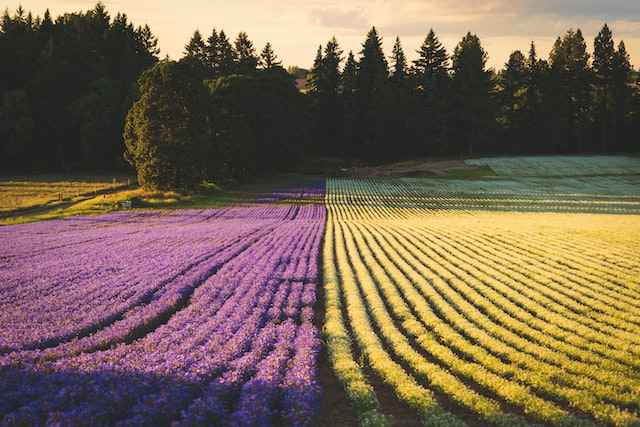

## Merging VCF Files

The first thing we need to to is zip and then index the individual vcf files. As a reminder, these files have been created by individual `freebayes` SNP calling of chunks of individuals partitioned into groups based upon the first letter of the popualtion from which they were collected. So, in the following examples, the file `R.vcf` contains all the individuals in populations starting with the letter `R`. When there are not that many individuals in a group, they are clustered—below we have `JK.vcf` which has all the individuals from populations starting with the letters `J` and `K`.

So, lets compress these raw files first.

```bash
% bgzip JK.vcf
% bgzip P.vcf
% bgzip R.vcf
% bgzip S.vcf
% bgzip W.vcf
% ls -alh
total 70032
drwxr-xr-x   7 rodney  staff   224B Feb 16 14:22 .
drwxr-xr-x  21 rodney  staff   672B Feb 16 14:10 ..
-rw-r--r--   1 rodney  staff   3.1M Feb 16 14:20 JK.vcf.gz
-rw-r--r--   1 rodney  staff   5.8M Feb 16 14:22 P.vcf.gz
-rw-r--r--   1 rodney  staff   4.6M Feb 16 14:22 R.vcf.gz
-rw-r--r--   1 rodney  staff    14M Feb 16 14:22 S.vcf.gz
-rw-r--r--   1 rodney  staff   5.8M Feb 16 14:22 W.vcf.gz
```

Now we need to index these files.

```bash
% tabix -p vcf JK.vcf.gz
% tabix -p vcf P.vcf.gz
% tabix -p vcf R.vcf.gz
% tabix -p vcf S.vcf.gz
% tabix -p vcf W.vcf.gz
```

Then we can merge the files together into a single file. Here, the output file indicates the populations that contribute to it.

```bash
 % vcf-merge JK.vcf.gz P.vcf.gz R.vcf.gz S.vcf.gz W.vcf.gz > JKPRSW.vcf
```

So here are a few things that I’ve found that provide some insights into the data we are getting. Here is the sequencing depth per individual for only the SNP sites who have a minimum quality score of 20.

```bash
% vcftools --vcf JKPRSW.vcf --remove-indels --minQ 20 --depth -c > depth.txt
```

This produced a distribution of sequencing depths for these individuals.

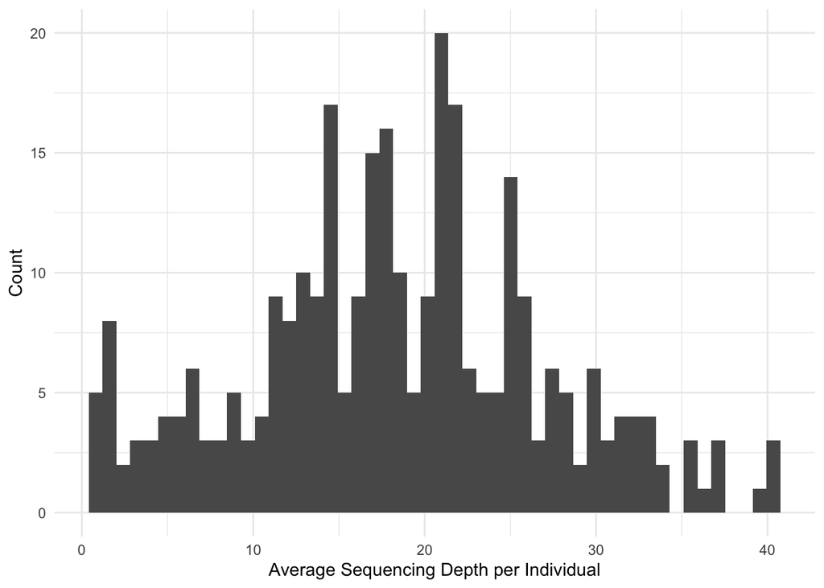

Figure 1 Average sequencing depth across loci within each of the 302 individuals.

Alternatively—and perhaps more important for us—we can look at the per-site depths. The goal here is to retain sites that have enough sequencing depth such that we are confident that it is a good site but not too much such that it is a reapeaty region in the geniome. For simplicity, I’ll drop the lower and upper standard deviation.

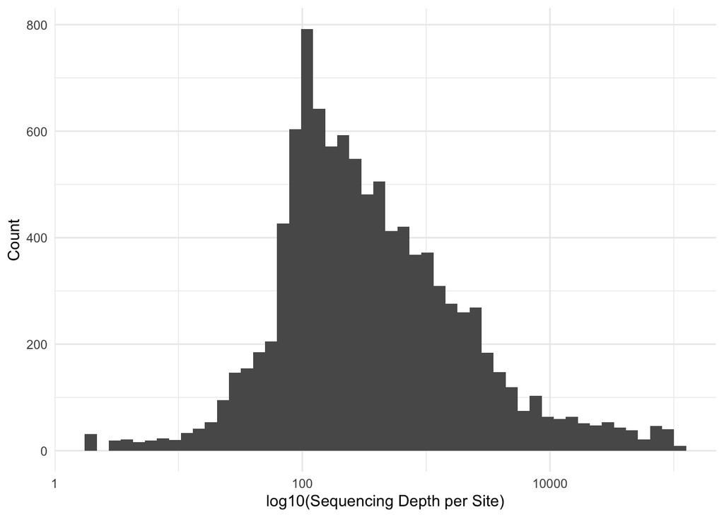

Figure 2 Average sequencing depth per site across 302 individuals.

For simplicity, I’m just going to take the inner-50% of the data, dropping off the lower and upper quantiles.

```r
quantile( site_depth$SUM_DEPTH,
          prob = c(0.10,0.25, 0.5, 0.75, 0.90))
```

```
   10%    25%    50%    75%    90%
  60.0  110.0  278.0  964.0 3421.1
```

Now, we can go back to `vcftools` and use these values to select only sites with a quality score exceeding 20, and are in the middle 50 percentile of the depth coverage and have a minor allele frequency of at least 5%.

```bash
% vcftools --vcf JKPRSW.vcf --remove-indels --min-meanDP 110 --max-meanDP 964 --minQ 20 --maf 0.05  --min-alleles 2 --max-alleles 2 --freq
After filtering, kept 302 out of 302 Individuals
Outputting Frequency Statistics...
After filtering, kept 120 out of a possible 22604 Sites
Run Time = 1.00 seconds
```

So, we have 120 loci to work with from this subset.

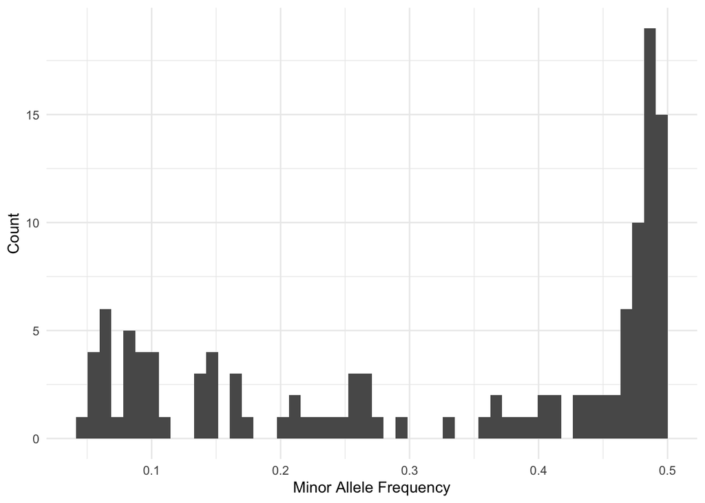

### Filtering out Sequncing Errors

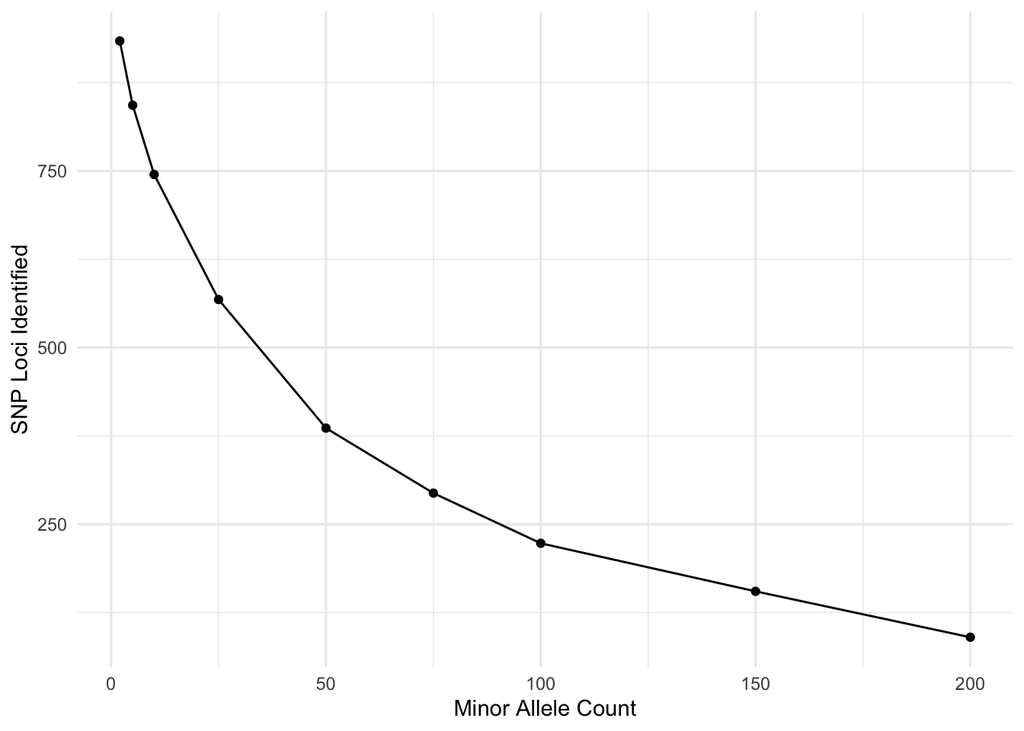

Nubmer of filtered SNP loci across a range of stringency in the minimum number of times a minor allele is observed across the data set.

```r
tribble( ~MAC, ~SNPs,
         2,  934,
         5,  843,
         10, 745,
         25, 568,
         50, 386,
         75, 294,
         100, 223,
         150, 155,
         200, 90) %>%
  mutate( p = MAC/(2*1419)) %>%
  ggplot( aes(MAC, SNPs) ) +
  geom_line() +
  geom_point() +
  xlab("Minor Allele Count") +
  ylab("SNP Loci Identified")
```

I am sure there is a probability example that could be used here to look at where you break even on sequencing errors and joint probability of the same allele being *incorrectly* identified. Don’t quite want to work it out right now but I think my 5% (putting it just shy of the MAC=150) may have been a bit too stringent…

### Filtering on Depth

Next lets look at sequencing depth. Here i am going to fix the MAC=5 and cut off all the loci that have a depths in excess of the 90% in depths (see above) and then look at how many loci are recovered going from 5X coverage up to 200X (the example above had it set at a minimum coverage of 110X).

[figure not shown]

```r
tribble( ~`Minimum Depth`, ~SNPs,
         5,  1519,
         10, 843,
         25, 459,
         50, 298,
         75, 226,
         100, 166,
         150, 110,
         200, 85) %>%
  ggplot( aes(`Minimum Depth`, SNPs) ) +
  geom_line() +
  geom_point() +
  xlab("Minor Allele Count") +
  ylab("SNP Loci Identified")
```